# PairWisePlotting

[figure not shown]

- “A picture is worth a thousand words”
- Data visualization is important because it allows us to access huge amount of numerical data in easily digestible visuals
  - Data graphics are simplest but powerful
  - Graphical presentation of information enables efficient cognition and promotes effective management decisions

```python
import pandas as pd
import numpy as np
import seaborn as sns
import matplotlib.pyplot as plt
```

# Seaborn Library:

Seaborn is a Python visualization library based on matplotlib. It provides a high-level interface for drawing attractive statistical graphics

# IRIS Dataset:

The data set consists of 50 samples from each of three species of Iris (Iris setosa, Iris virginica and Iris versicolor). Four features were measured from each sample: the length and the width of the sepals and petals, in centimetres.

```python
iris = sns.load_dataset("iris")
iris.head()
```

|  | sepal_length | sepal_width | petal_length | petal_width | species |
| --- | --- | --- | --- | --- | --- |
| 0 | 5.1 | 3.5 | 1.4 | 0.2 | setosa |
| 1 | 4.9 | 3.0 | 1.4 | 0.2 | setosa |
| 2 | 4.7 | 3.2 | 1.3 | 0.2 | setosa |
| 3 | 4.6 | 3.1 | 1.5 | 0.2 | setosa |
| 4 | 5.0 | 3.6 | 1.4 | 0.2 | setosa |

# JOINT PLOT

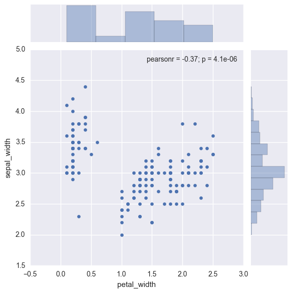

```python
x1=iris.petal_width
y1=iris.sepal_width
g1 = sns.jointplot(x1, y1)
sns.plt.show()
```

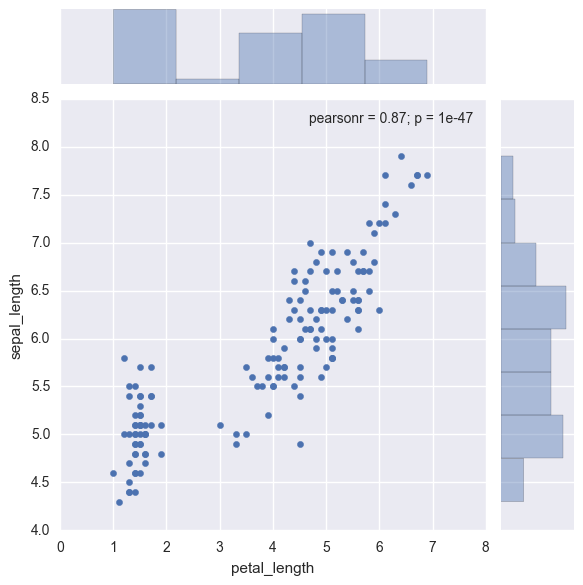

```python
x2=iris.petal_length
y2=iris.sepal_length
g2 = sns.jointplot(x2, y2)
sns.plt.show()
```

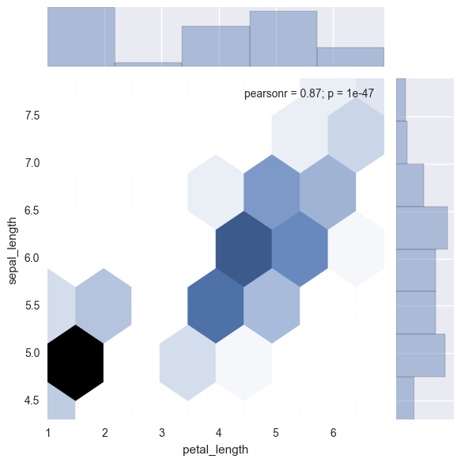

```python
g3 = sns.jointplot(x2, y2, kind="hex")
sns.plt.show()
```

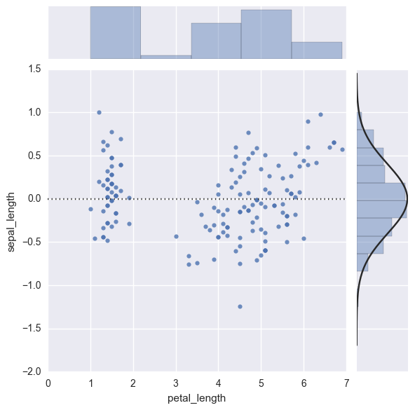

```python
g4 = sns.jointplot(x2, y2, kind="resid")
sns.plt.show()
```

# Pairwise Plotting

Compare one independent variable with many dependent variables

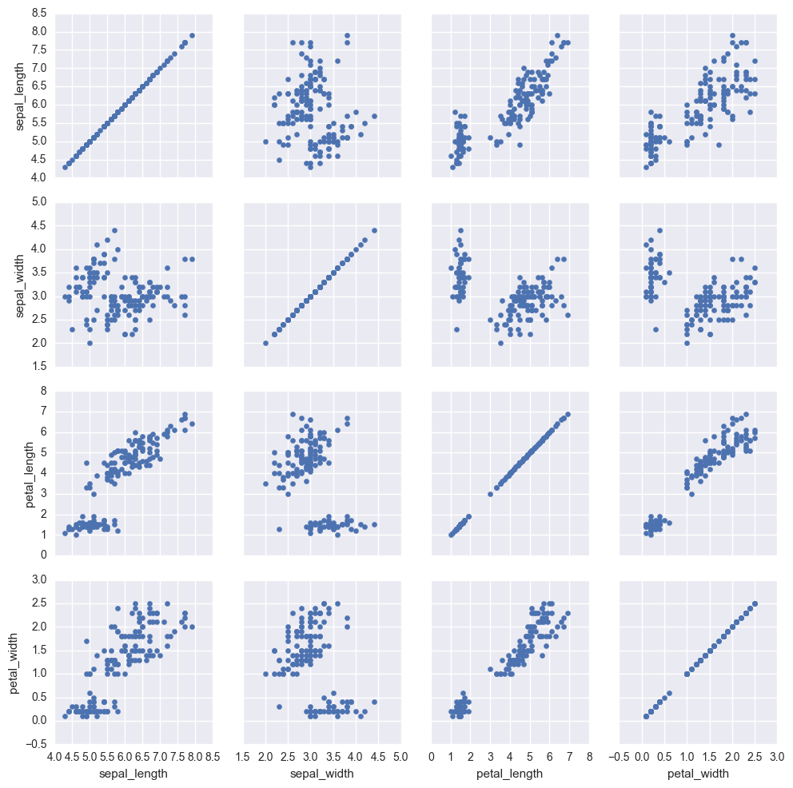

```python
iris = sns.load_dataset("iris")
g = sns.PairGrid(iris)
g = g.map(plt.scatter)
sns.plt.show()
```

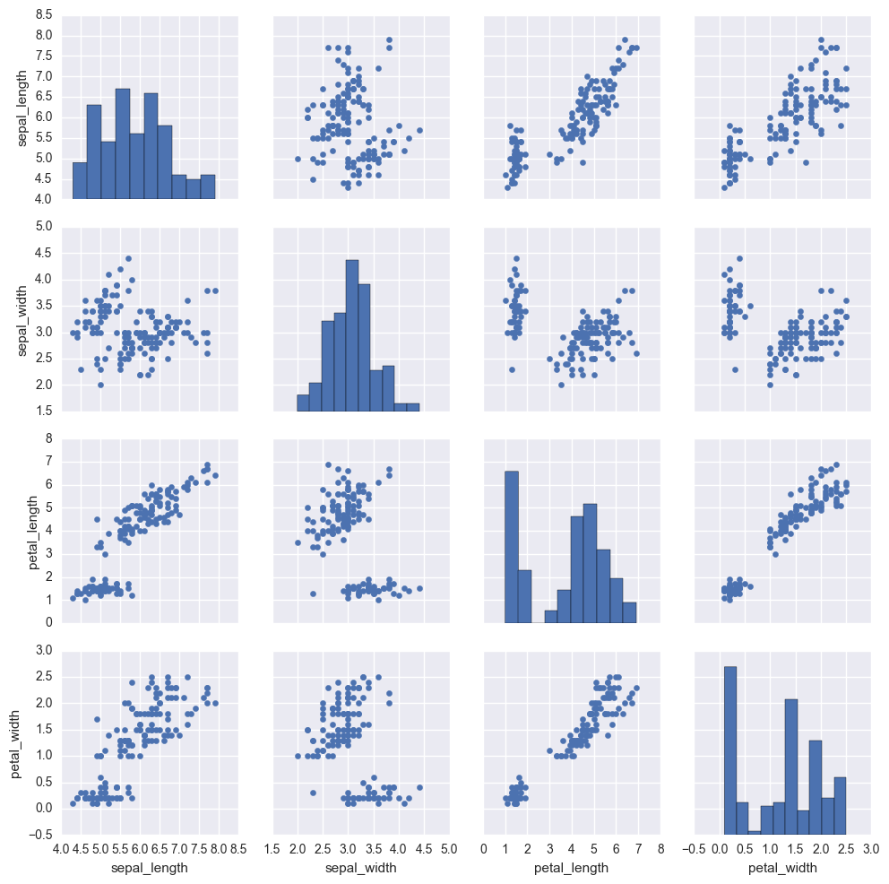

```python
g = sns.PairGrid(iris)
g = g.map_diag(plt.hist)
g = g.map_offdiag(plt.scatter)
sns.plt.show()
```

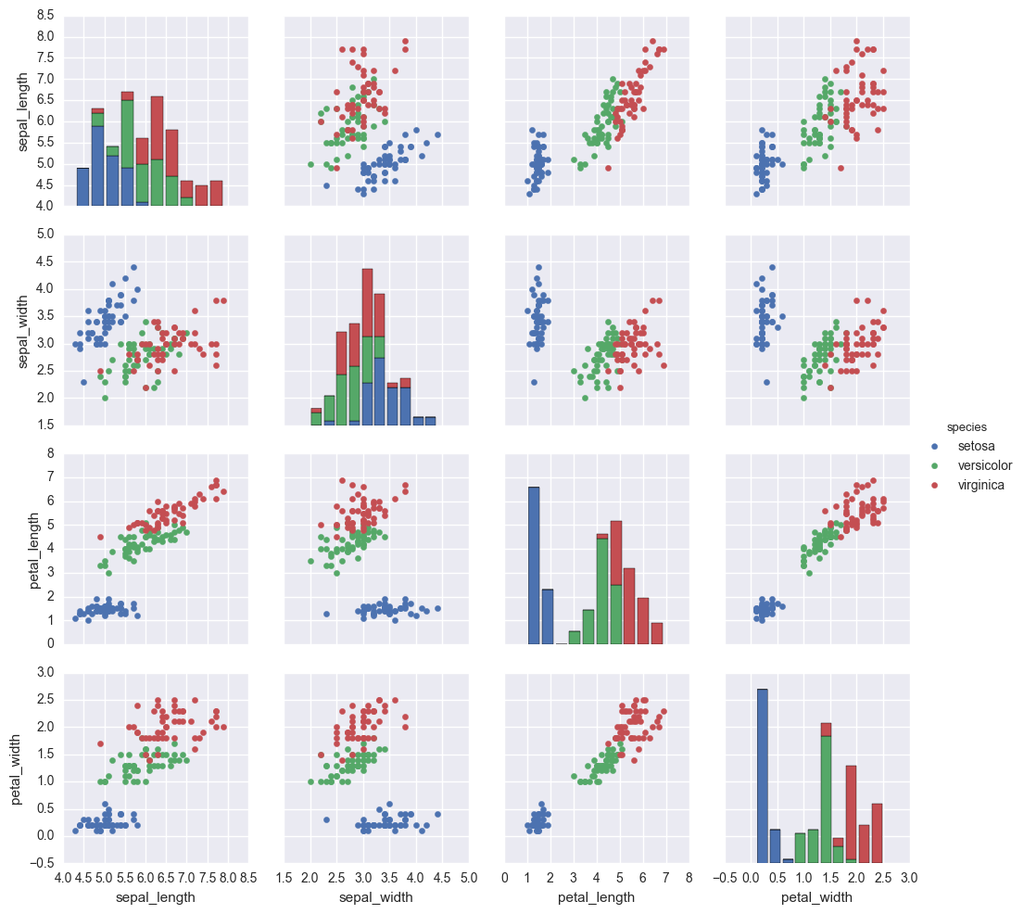

```python
g = sns.PairGrid(iris, hue="species")
g = g.map_diag(plt.hist)
g = g.map_offdiag(plt.scatter)
g = g.add_legend()
sns.plt.show()
```

# Kernel Density Estimation

- Kernel density estimation is typically known as its short form kde
- kernel density estimation is also known as the Parzen-Rosenblatt window method
- Its a non-parametric way to estimate the probability density function (pdf) for a variable (x)
  - Data is not required to fit normal distribution (fewer assumptions)
  - Mostly data is ordinal, does not rely on numbers but is ranking or order of sorts

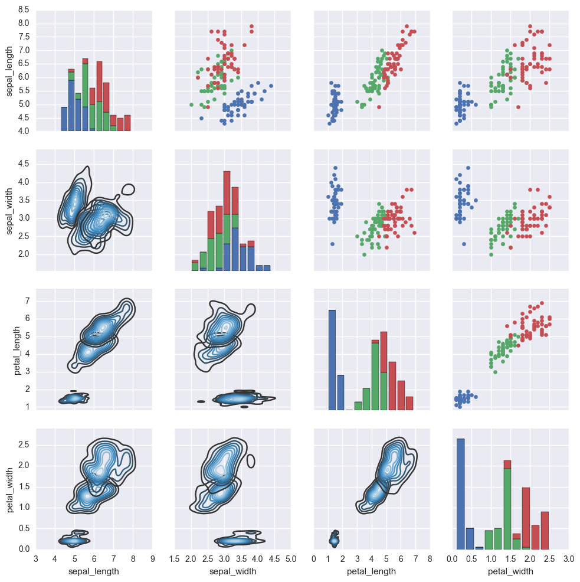

```python
g = sns.PairGrid(iris, hue='species')
g = g.map_upper(plt.scatter)
g = g.map_lower(sns.kdeplot, cmap="Blues_d")
#g = g.map_diag(sns.kdeplot)
g = g.map_diag(plt.hist)
sns.plt.show()
```

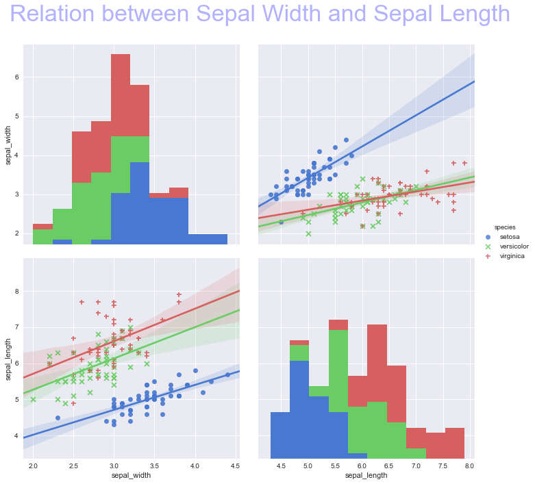

```python
# Create a Pairplot
g = sns.pairplot(iris,hue="species",palette="muted",size=5,
    vars=["sepal_width", "sepal_length"],kind='reg',markers=['o','x','+'])

# To change the size of the scatterpoints in graph
g = g.map_offdiag(plt.scatter,  s=35,alpha=0.5)

# Additional line to adjust some appearance issue
plt.subplots_adjust(top=0.9)
g.fig.suptitle('Relation between Sepal Width and Sepal Length',
    fontsize=34,color="b",alpha=0.3)
sns.plt.show()
```